# Manage Environments

[[edit on GitHub]](https://github.com/chef/chef-web-docs/blob/main/content/server_manage_environments.md)

[figure not shown]

Warning

Chef Manage is deprecated and no longer under active development. It is supported on Chef Automate installations up to version 1.8 and replaced by Chef Automate 2.0. Contact your Chef account representative for information about upgrading your system. See our Automate documentation to learn more about Chef Automate 2.

This document is no longer maintained.

Note

This topic is about using the Chef management console to manage environments.

Note

Chef Manage in all versions can only display 20 Environment items from the Chef Server search index.

An environment is a way to map an organization’s real-life workflow to what can be configured and managed when using Chef Infra. This mapping is accomplished by setting attributes and pinning cookbooks at the environment level. With environments, you can change cookbook configurations depending on the system’s designation. For example, by designating different staging and production environments, you can then define the correct URL of a database server for each environment. Environments also allow organizations to move new cookbook releases from staging to production with confidence by stepping releases through testing environments before entering production.

## Manage

Environments can be managed from the Chef management console web user interface.

### Add Environment

To add an environment:

1. Open the Chef management console.
2. Click **Policy**.
3. Click **Environments**.
4. Click **Create**.
5. In the **Create an Environment** dialog box, enter the name of the environment and a description.

[figure not shown]

   Click **Next**.
6. Optional. Set a constraint by choosing a name, an operator, and a version:

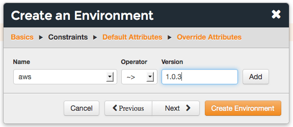

   Click **Add**. Continue this process until all constraints are added. When finished, click **Next**.
7. Optional. Add default attributes as JSON data:

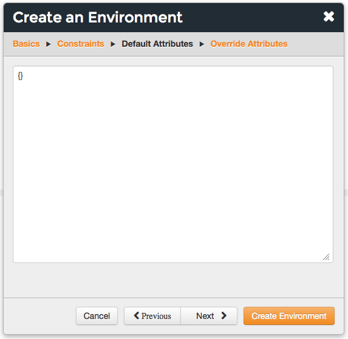

   Click **Next**.
8. Optional. Add override attributes as JSON data:

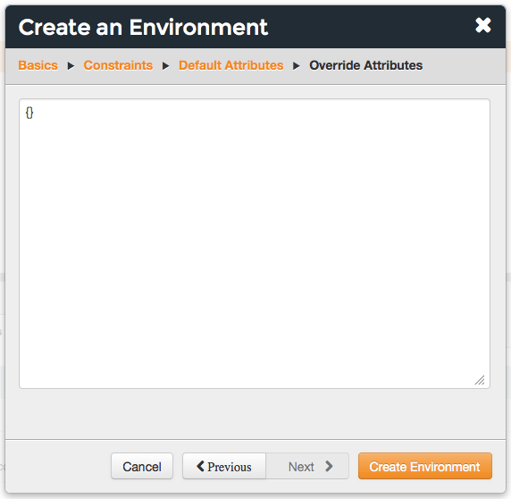

9. Click **Create Environment**.

### Delete Environment

To delete an environment:

1. Open the Chef management console.
2. Click **Policy**.
3. Click **Environments**.
4. Select an environment.
5. Click **Delete**.

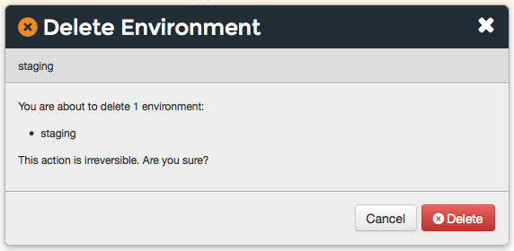

### Edit Details

To edit the details of an environment:

1. Open the Chef management console.
2. Click **Policy**.
3. Click **Environments**.
4. Select an environment.
5. Click the **Details** tab.
6. Click **Edit**.

### Set

To set the environment for a node:

1. Open the Chef management console.
2. Click **Nodes**.
3. Select a node.
4. Click the **Details** tab.
5. In the top right, from the **Environment** drop-down, select the environment:

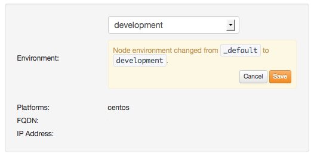

6. Click **Save**.

### View Details

To view environment details:

1. Open the Chef management console.
2. Click **Policy**.
3. Click **Environments**.
4. Select an environment.
5. Click the **Details** tab.

## Default Attributes

A `default` attribute is automatically reset at the start of every Chef Infra Client run and has the lowest attribute precedence. Use `default` attributes as often as possible in cookbooks.

### Edit

To edit default attributes for an environment:

1. Open the Chef management console.
2. Click **Policy**.
3. Click **Environments**.
4. Select an environment.
5. Click the **Attributes** tab.
6. Under **Default Attributes**, click **Edit**.
7. In the **Edit Environment Attributes** dialog box, enter the JSON data that defines the attribute (or attributes).

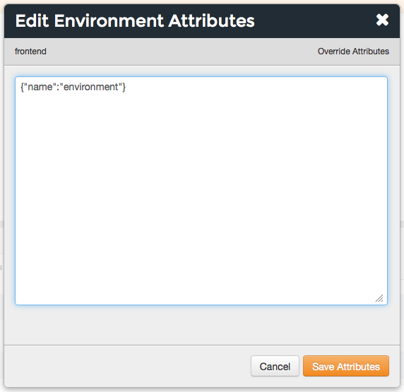

### View

To view default attributes for an environment:

1. Open the Chef management console.
2. Click **Policy**.
3. Click **Environments**.
4. Select an environment.
5. Click the **Attributes** tab.

## Override Attributes

An `override` attribute is automatically reset at the start of every Chef Infra Client run and has a higher attribute precedence than `default`, `force_default`, and `normal` attributes. An `override` attribute is most often specified in a recipe, but can be specified in an attribute file, for a role, and/or for an environment. A cookbook should be authored so that it uses `override` attributes only when required.

### Edit

To edit override attributes for an environment:

1. Open the Chef management console.
2. Click **Policy**.
3. Click **Environments**.
4. Select an environment.
5. Click the **Attributes** tab.
6. Under **Override Attributes**, click **Edit**.
7. In the **Edit Environment Attributes** dialog box, enter the JSON data that defines the attribute (or attributes).

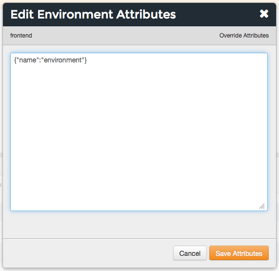

8. Click **Save Attributes**.

### View

To view override attributes for an environment:

1. Open the Chef management console.
2. Click **Policy**.
3. Click **Environments**.
4. Select an environment.
5. Click the **Attributes** tab.

## Permissions

Permissions are used in the Chef Infra Server to define how users and groups can interact with objects on the server. Permissions are configured per-organization.

The Chef Infra Server includes the following object permissions:

[output not shown]

### Set

To set permissions list for an environment object:

1. Open the Chef management console.
2. Click **Policy**.
3. Click **Environments**.
4. Select an environment.
5. Click the **Permissions** tab.
6. For each group listed under **Name**, select or de-select the **Read**, **Update**, **Delete**, and **Grant** permissions.

### Update

To update the permissions list for an environment object:

1. Open the Chef management console.
2. Click **Policy**.
3. Click **Environments**.
4. Select an environment.
5. Click the **Permissions** tab.
6. Click the **+ Add** button and enter the name of the user or group to be added.
7. Select or de-select **Read**, **Update**, **Delete**, and **Grant** to update the permissions list for the user or group.

### View

To view permissions for an environment object:

1. Open the Chef management console.
2. Click **Policy**.
3. Click **Environments**.
4. Select an environment.
5. Click the **Permissions** tab.
6. Set the appropriate permissions: **Read**, **Update**, **Delete**, and **Grant**.